[figure not shown]

# UFCFFY-15-M Cyber Security Analytics

## Practical Lab 10: Text Analytics

In this lab, we will begin to experiment with text analytics in the context of a fake news investigation. We show how to use the TF-IDF method of identifying key terms in a text corpus, and training a machine learning model based on this. We also explore the IF-IDF further to understand what this represents for our document set.

```python
!pip install pandas numpy matplotlib seaborn wordcloud sklearn
#! pip install nltk

#Basic libraries
import pandas as pd
import numpy as np

#Visualization libraries
import matplotlib.pyplot as plt
import seaborn as sns

#Miscellanous libraries
from collections import Counter

#Ignore warnings
import warnings
warnings.filterwarnings('ignore')
```

```python
#reading the fake and true datasets
fake_news = pd.read_csv('./example_data/Fake.csv')
true_news = pd.read_csv('./example_data/True.csv')

print ("Fake news: ", fake_news.shape)
print ("True news: ", true_news.shape)
```

```
Fake news:  (23481, 4)
True news:  (21417, 4)
```

```python
fake_news.head(10)
```

|  | title | text | subject | date |
| --- | --- | --- | --- | --- |
| 0 | Donald Trump Sends Out Embarrassing New Year’... | Donald Trump just couldn t wish all Americans ... | News | December 31, 2017 |
| 1 | Drunk Bragging Trump Staffer Started Russian ... | House Intelligence Committee Chairman Devin Nu... | News | December 31, 2017 |
| 2 | Sheriff David Clarke Becomes An Internet Joke... | On Friday, it was revealed that former Milwauk... | News | December 30, 2017 |
| 3 | Trump Is So Obsessed He Even Has Obama’s Name... | On Christmas day, Donald Trump announced that ... | News | December 29, 2017 |
| 4 | Pope Francis Just Called Out Donald Trump Dur... | Pope Francis used his annual Christmas Day mes... | News | December 25, 2017 |
| 5 | Racist Alabama Cops Brutalize Black Boy While... | The number of cases of cops brutalizing and ki... | News | December 25, 2017 |
| 6 | Fresh Off The Golf Course, Trump Lashes Out A... | Donald Trump spent a good portion of his day a... | News | December 23, 2017 |
| 7 | Trump Said Some INSANELY Racist Stuff Inside ... | In the wake of yet another court decision that... | News | December 23, 2017 |
| 8 | Former CIA Director Slams Trump Over UN Bully... | Many people have raised the alarm regarding th... | News | December 22, 2017 |
| 9 | WATCH: Brand-New Pro-Trump Ad Features So Muc... | Just when you might have thought we d get a br... | News | December 21, 2017 |

```python
true_news.head(10)
```

|  | title | text | subject | date |
| --- | --- | --- | --- | --- |
| 0 | As U.S. budget fight looms, Republicans flip t... | WASHINGTON (Reuters) - The head of a conservat... | politicsNews | December 31, 2017 |
| 1 | U.S. military to accept transgender recruits o... | WASHINGTON (Reuters) - Transgender people will... | politicsNews | December 29, 2017 |
| 2 | Senior U.S. Republican senator: 'Let Mr. Muell... | WASHINGTON (Reuters) - The special counsel inv... | politicsNews | December 31, 2017 |
| 3 | FBI Russia probe helped by Australian diplomat... | WASHINGTON (Reuters) - Trump campaign adviser ... | politicsNews | December 30, 2017 |
| 4 | Trump wants Postal Service to charge 'much mor... | SEATTLE/WASHINGTON (Reuters) - President Donal... | politicsNews | December 29, 2017 |
| 5 | White House, Congress prepare for talks on spe... | WEST PALM BEACH, Fla./WASHINGTON (Reuters) - T... | politicsNews | December 29, 2017 |
| 6 | Trump says Russia probe will be fair, but time... | WEST PALM BEACH, Fla (Reuters) - President Don... | politicsNews | December 29, 2017 |
| 7 | Factbox: Trump on Twitter (Dec 29) - Approval ... | The following statements were posted to the ve... | politicsNews | December 29, 2017 |
| 8 | Trump on Twitter (Dec 28) - Global Warming | The following statements were posted to the ve... | politicsNews | December 29, 2017 |
| 9 | Alabama official to certify Senator-elect Jone... | WASHINGTON (Reuters) - Alabama Secretary of St... | politicsNews | December 28, 2017 |

```python
fake_news.iloc[0]['text']
```

```
'Donald Trump just couldn t wish all Americans a Happy New Year and leave it at that. Instead, he had to give a shout out to his enemies, haters and  the very dishonest fake news media.  The former reality show star had just one job to do and he couldn t do it. As our Country rapidly grows stronger …
```

## Example: TF-IDF Vectoriser

```python
from sklearn.feature_extraction.text import TfidfVectorizer
corpus = [
    'This is the first document.',
    'This document is the second document.',
    'And this is the third one.',
    'Is this the first document?',
]
vectorizer = TfidfVectorizer()
X = vectorizer.fit_transform(corpus)
X
```

```
<4x9 sparse matrix of type '<class 'numpy.float64'>'
	with 21 stored elements in Compressed Sparse Row format>
```

```python
X.todense()
```

```
matrix([[0.        , 0.46979139, 0.58028582, 0.38408524, 0.        ,
         0.        , 0.38408524, 0.        , 0.38408524],
        [0.        , 0.6876236 , 0.        , 0.28108867, 0.        ,
         0.53864762, 0.28108867, 0.        , 0.28108867],
        [0.51184851, 0.        , 0.        , 0.26710379, 0.51184851,
         0.        , 0.26710379, 0.51184851, 0.26710379],
        [0.        , 0.46979139, 0.58028582, 0.38408524, 0.        ,
         0.        , 0.38408524, 0.        , 0.38408524]])
```

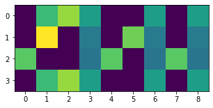

```python
plt.figure(figsize=(5,5))
plt.imshow(X.todense())
plt.show()
```

```python
X.shape
```

```
(4, 9)
```

```python
vectorizer.get_feature_names_out()
```

```
array(['and', 'document', 'first', 'is', 'one', 'second', 'the', 'third',
       'this'], dtype=object)
```

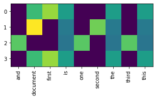

```python
plt.figure(figsize=(5,5))
plt.imshow(X.todense())
plt.xticks(list(range(X.shape[1])), labels=vectorizer.get_feature_names_out(), rotation=90)
plt.show()
```

# Let's try this on our Fake News Dataset....

We will start with a simple approach, where we now take 5 articles from each class, and build a TF-IDF vector as above.

```python
from sklearn.feature_extraction.text import TfidfVectorizer
corpus = [
    fake_news.iloc[0]['text'],
    fake_news.iloc[1]['text'],
    fake_news.iloc[2]['text'],
    fake_news.iloc[3]['text'],
    fake_news.iloc[4]['text'],
    true_news.iloc[0]['text'],
    true_news.iloc[1]['text'],
    true_news.iloc[2]['text'],
    true_news.iloc[3]['text'],
    true_news.iloc[4]['text'],
]
vectorizer = TfidfVectorizer()
X = vectorizer.fit_transform(corpus)
X
```

```
<10x1590 sparse matrix of type '<class 'numpy.float64'>'
	with 2650 stored elements in Compressed Sparse Row format>
```

```python
X.todense()
```

```
matrix([[0.        , 0.02440592, 0.        , ..., 0.        , 0.        ,
         0.        ],
        [0.        , 0.        , 0.        , ..., 0.        , 0.        ,
         0.        ],
        [0.        , 0.        , 0.        , ..., 0.        , 0.03062055,
         0.        ],
        ...,
        [0.        , 0.        , 0.        , ..., 0.        , 0.        ,
         0.        ],
        [0.        , 0.        , 0.        , ..., 0.        , 0.        ,
         0.        ],
        [0.        , 0.01480304, 0.0199038 , ..., 0.        , 0.        ,
         0.        ]])
```

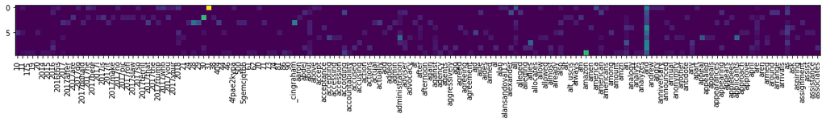

```python
plt.figure(figsize=(20,10))
start_n = 0
end_n = 160
data = X.todense()[:, start_n:end_n]
labels = vectorizer.get_feature_names_out()[start_n:end_n]
plt.imshow(data)
plt.xticks(list(range(start_n,end_n)), labels=labels, rotation=90)
plt.show()
```

The matrix above gives a visual representation of occurrence between classes for each word - note words such as **and** are clearly across all classes, whilst others may only have membership to fake (top 5 rows) or true (bottom 5 rows) classes.

```python
# set the labels manually since we have a small set of 5 fake and 5 true
y = [0,0,0,0,0,1,1,1,1,1]
```

```python
# create a simple classifier - trained only on our 5 examples of each class
from sklearn.neural_network import MLPClassifier
clf = MLPClassifier(random_state=1, max_iter=300).fit(X, y)
```

```python
# predict the probabilities of the training examples - shows the class separation
clf.predict_proba(X)
```

```
array([[0.99275323, 0.00724677],
       [0.99100087, 0.00899913],
       [0.99554437, 0.00445563],
       [0.99333115, 0.00666885],
       [0.99251297, 0.00748703],
       [0.00353847, 0.99646153],
       [0.0056744 , 0.9943256 ],
       [0.00630346, 0.99369654],
       [0.00840374, 0.99159626],
       [0.00557062, 0.99442938]])
```

# Using the classifier on a new test dataset

We draw 5 new samples of each class to try.

```python
# now let's try a new test set of data - draw some examples from our full dataset

new_corpus = [
    fake_news.iloc[10]['text'],
    fake_news.iloc[11]['text'],
    fake_news.iloc[12]['text'],
    fake_news.iloc[13]['text'],
    fake_news.iloc[14]['text'],
    true_news.iloc[10]['text'],
    true_news.iloc[11]['text'],
    true_news.iloc[12]['text'],
    true_news.iloc[13]['text'],
    true_news.iloc[14]['text'],
]

# here we transform our corpus to the TF-IDF vector - NOTE: we transform only, we do not fit again as we are testing not training.
new_X = vectorizer.transform(new_corpus)
# here we predict probabilities of new_X using our trained clf classifier...
clf.predict_proba(new_X)
```

```
array([[0.42758047, 0.57241953],
       [0.48673985, 0.51326015],
       [0.35945337, 0.64054663],
       [0.43636145, 0.56363855],
       [0.28241462, 0.71758538],
       [0.15684186, 0.84315814],
       [0.11243396, 0.88756604],
       [0.40300811, 0.59699189],
       [0.57990193, 0.42009807],
       [0.24019662, 0.75980338]])
```

Note that the probabilities are not as strongly weighted as they were earlier - shows the limited capability of this initial model (it was trained on a **very** small dataset). Can we improve this - let's try training a model on our full dataset (this will take us longer, but will learn from more data).

```python
# now let's try a new test set of data - draw some examples from our full dataset

final_corpus = []
final_labels = []

for row in range(fake_news.shape[0]):
    final_corpus.append(fake_news.iloc[row]['text'])
    final_labels.append(0)
for row in range(true_news.shape[0]):
    final_corpus.append(true_news.iloc[row]['text'])
    final_labels.append(1)

new_X = vectorizer.fit_transform(final_corpus)
```

```python
from sklearn.model_selection import train_test_split
X_train, X_test, y_train, y_test = train_test_split(new_X, final_labels, test_size=0.3, random_state=100)
```

```python
from sklearn.neural_network import MLPClassifier
clf = MLPClassifier(random_state=1, max_iter=300).fit(X_train, y_train)
```

```python
np.round(clf.predict_proba(X_test))[0:10]
```

```
array([[1., 0.],
       [0., 1.],
       [0., 1.],
       [0., 1.],
       [1., 0.],
       [0., 1.],
       [0., 1.],
       [1., 0.],
       [0., 1.],
       [1., 0.]])
```

```python
y_test[:10]
```

```
[0, 1, 1, 1, 0, 1, 1, 0, 1, 0]
```

```python
clf.score(X_test, y_test)
```

```
0.9911655530809206
```

Here we can inspect the predictions for the first 10 instances to assess whether they are correct. We also achieve an overall accuracy score of **99.116%** with the complete dataset.